# The Anatomy of a Plot

Daniel Marcelino

2016-07-05

# 1 Overview

This document presents several wrapper functions to make plotting with ggplot2 a lot easier.

# 2 Preview ggplot2 themes

Graph() can be used to preview ggplot2 themes and features.

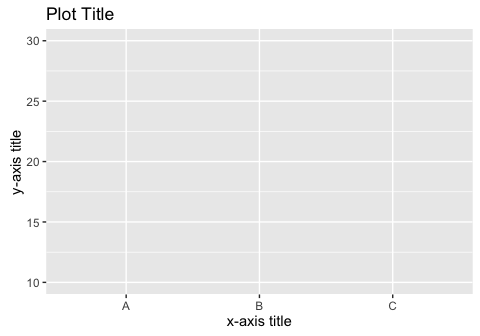

```r
library("SciencesPo", quietly = TRUE)

Graph()
```

# 3 Themes

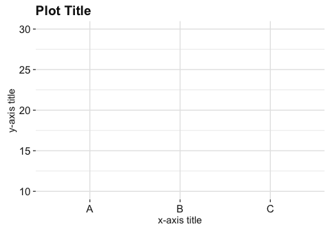

```r
Graph() + theme_pub()
```

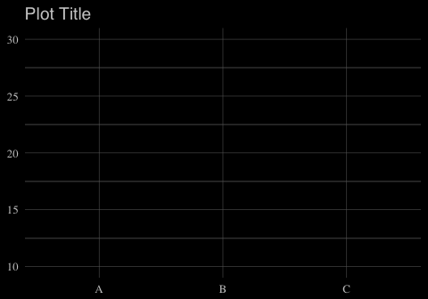

```r
Graph() + theme_darkside()
```

```r
Graph() + theme_blank()
```

[output not shown]

# 4 Title

## 4.1 Align title right

Align ggplot2 title to the right.

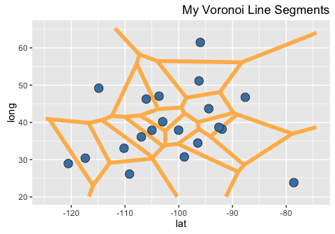

```r
gg + align_title_right()
```

## 4.2 Align title left

Align ggplot2 title to the left.

```r
gg + align_title_left()
```

[output not shown]

## 4.3 Remove ggplot2 title

Do not show plot title.

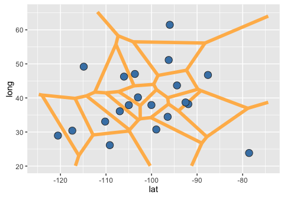

```r
gg + no_title()
```

# 5 Plot Axes

## 5.1 Remove ggplot2 x-axis

Remove the x axis from a ggplot2 including the axis lines, titles, labels and ticks.

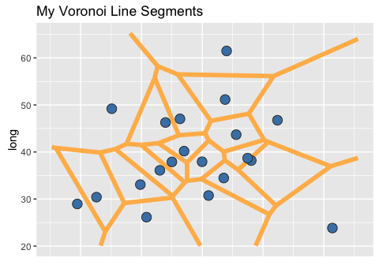

```r
gg + no_x_axis()
```

## 5.2 Remove ggplot2 y-axis

Remove the y axis from a ggplot2 including the axis lines, titles, labels and ticks.

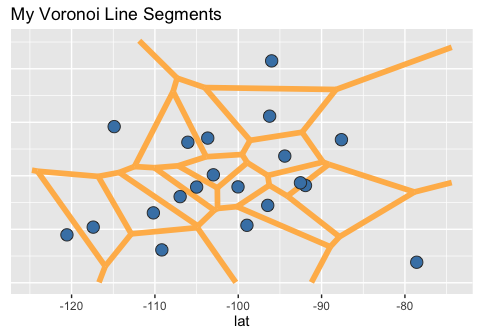

```r
gg + no_y_axis()
```

## 5.3 Remove ggplot2 Axes

Remove both axes from a ggplot2 including the axes lines, titles, labels and ticks.

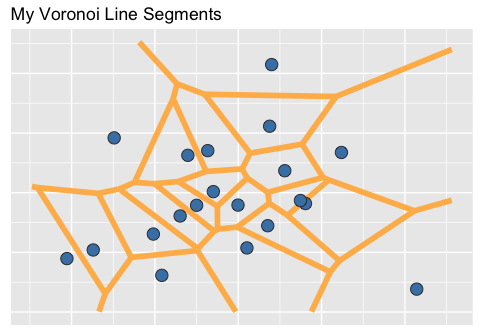

```r
gg + no_axes()
```

## 5.4 Remove ggplot2 x-axis line

Do not show x-axis line.

```r
gg + no_x_line()
```

[output not shown]

```r
gg + no_x_line()
```

## 5.6 Remove ggplot2 x-axis text/labels

Do not show x-axis text/labels

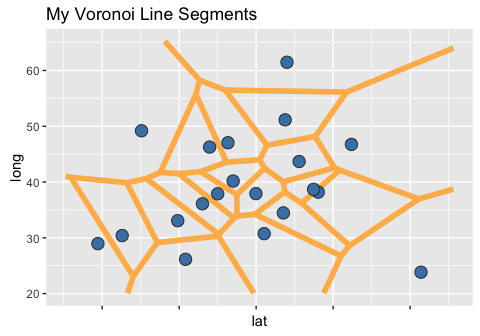

```r
gg + no_x_text()
```

## 5.7 Remove ggplot2 y-axis text/labels

Do not show y-axis text/labels.

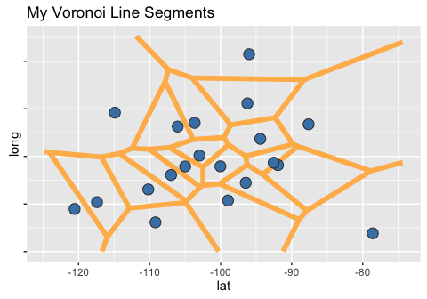

```r
gg + no_y_text()
```

## 5.8 Remove ggplot2 x-axis tick marks

Do not show tick marks for x-axis.

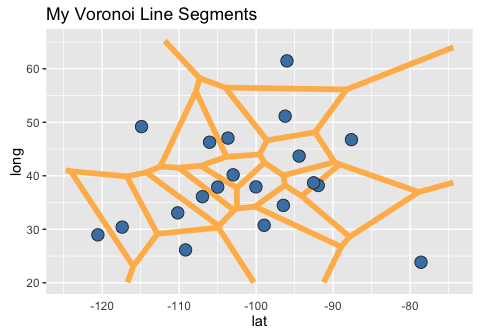

```r
gg + no_x_ticks()
```

## 5.9 Remove ggplot2 y-axis tick marks

Do not show tick marks for y-axis.

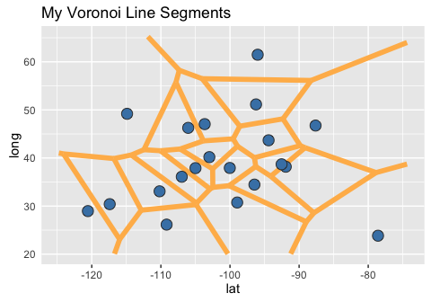

```r
gg + no_y_ticks()
```

## 5.10 Remove ggplot2 tick marks

Do not show tick marks for all axes.

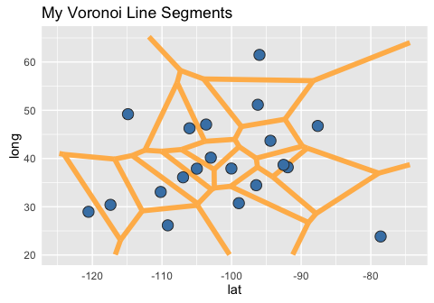

```r
gg + no_ticks()
```

## 5.11 Remove ggplot2 x-axis titles

Do not show x-axis title.

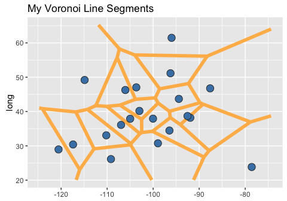

```r
gg + no_x_title()
```

## 5.12 Remove ggplot2 y-axis titles

Do not show y-axis title.

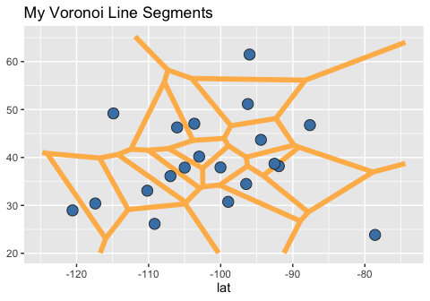

```r
gg + no_y_title()
```

## 5.13 Remove ggplot2 axes titles

Do not show titles for all axes.

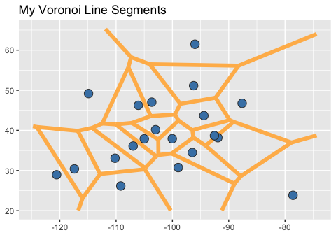

```r
gg + no_axes_titles()
```

## 5.14 Rotate ggplot2 x-axis labels

Rotate the x-axis labels/text by a given angle.

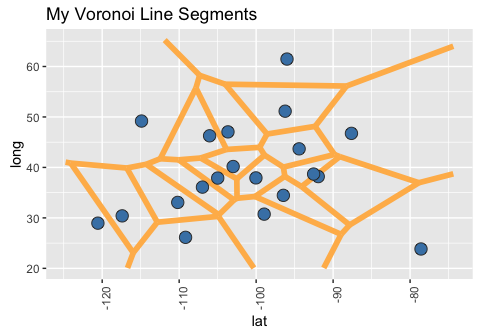

```r
gg + rotate_x_text(90)
```

## 5.15 Rotate ggplot2 y-axis labels

Rotate the y-axis labels/text by a given angle.

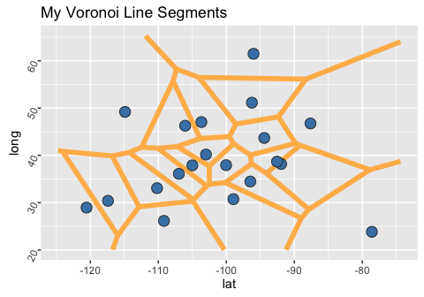

```r
gg + rotate_y_text(65)
```

## 5.16 Rotate ggplot2 axes labels

Rotate both axes labels by a given angle.

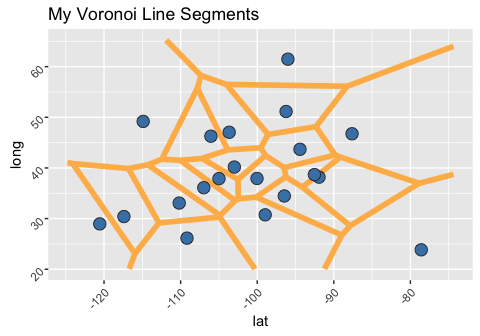

```r
gg + rotate_axes_text(45)
```

# 6 Plot Gridlines

## 6.1 Remove vertical gridlines

Remove all major and minor vertical gridlines from a ggplot2 plot or theme.

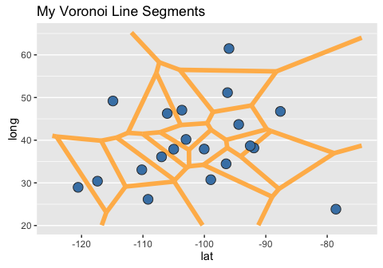

```r
gg + no_x_gridlines()
```

## 6.2 Remove horizontal gridlines

Remove all major and minor horizontal gridlines from a ggplot2 plot or theme.

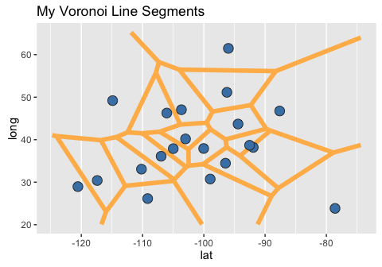

```r
gg + no_y_gridlines()
```

## 6.3 Remove all gridlines

Remove all vertical and horizontal gridlines (major and minor) from a ggplot2 plot or theme.

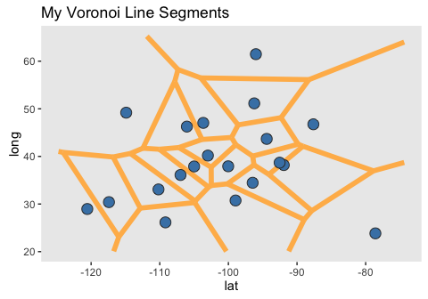

```r
gg + no_gridlines()
```

## 6.4 Remove major x gridlines

Do not show major gridlines for x-axis.

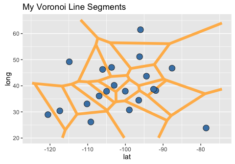

```r
gg + no_major_x_gridlines()
```

## 6.5 Remove major y gridlines

Do not show major gridlines for y-axis.

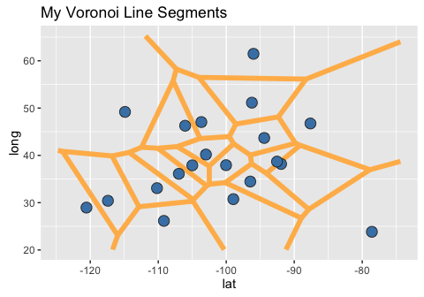

```r
gg + no_major_y_gridlines()
```

## 6.6 Remove major gridlines

Do not show major gridlines.

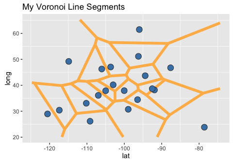

```r
gg + no_major_gridlines()
```

## 6.7 Remove minor vertical gridlines

Do not show minor gridlines for x-axis.

```r
gg + no_minor_x_gridlines()
```

[output not shown]

## 6.8 Remove minor horizontal gridlines

Do not show minor gridlines for y-axis.

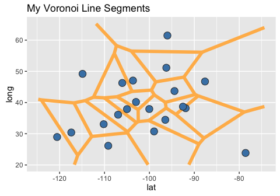

```r
gg + no_minor_y_gridlines()
```

## 6.9 Remove minor gridlines

Do not show minor gridlines.

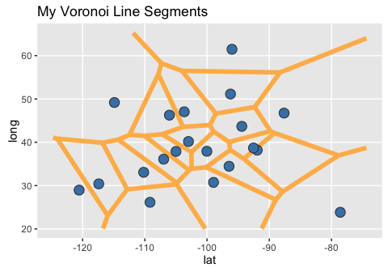

```r
gg + no_minor_gridlines()
```

# 7 Legend

## 7.1 Remove ggplot2 legend

Remove the legend from a ggplot2 plot.

```r
gg + no_legend()
```

## 7.2 Remove ggplot2 legend title

Remove the legend title from a ggplot2 plot.

```r
gg + no_legend_title()
```

## 7.3 Legend Position

Move legend to given location. The location of the legend is ‘top’, ‘bottom’, ‘right’, ‘left’ or ‘none’.

```r
gg + move_legend('bottom')
```

## 7.4 Legend to the bottom

Move a ggplot2 legend to the bottom of the plot.

```r
gg + legend_bottom()
```

## 7.5 Legend to the top

Move a ggplot2 legend to the top of the plot.

```r
gg + legend_top()
```

## 7.6 Legend to the left

Move a ggplot2 legend to the left of the plot.

```r
gg + legend_left()
```

## 7.7 Legend to the right

Move a ggplot2 legend to the right of the plot.

```r
gg + legend_right()
```